# Entrega: Tarea 1

Laura Basalo Tur, Camila Pérez Arévalo

7/11/2020

### Ejercicio 1

**The file *facebook_sample_anon.txt* is a data table containing the list of edges of an anonymized sample of the Facebook friendship network. Download it on your computer, upload it to R as a dataframe, and define an undirected graph with this list of edges.**

```r
#Cargamos los datos del fichero .txt en un dataframe
dataframe = read.table("data/facebook_sample_anon.txt",
                header = FALSE,
                col.names = c("nodeA", "nodeB"),
                sep = " ")

#Generamos el grafo no dirigido desde los datos del dataframe
undirected_graph = graph_from_data_frame(dataframe, directed=F)
```

**a) Is it connected? If it is not, replace it by its largest connected component.**

Un grafo es conexo si cada par de vértices está conectado por un camino; es decir, si para cualquier par de vértices (a, b), existe al menos un camino posible desde *‘a’* hacia *‘b’*.

Para comprobar si el grafo guardado en la variable *undirected_graph* es conexo se ha utilizado la función *is.connected*.

```r
is_connect = is.connected(undirected_graph)
```

El resultado obtenido es TRUE, por lo que podemos afirmar que el grafo es conexo.

**b) Compute the edge density.**

La densidad de un grafo es la relación entre el número de aristas del grafo y el número de aristas máximo. Para calcular la densidad se ha utilizado la función *edge_density*, indicando que no tenga en cuenta ningún posible loop del grafo.

```r
density = edge_density(undirected_graph, loops=F)
```

El resultado obtenido es 0.01082, por lo que podemos deducir que el grafo es disperso.

**c) What is the mean distance among the subjects?**

La distancia entre dos vértices de un grafo es el número de vértices mínimo que debe recorrerse para unirlos. Para calcula la media de esta distancia se ha utilizado la función *mean_distance*.

```r
mean_distance = mean_distance(undirected_graph, directed=F)
```

El resultado obtenido es 3.6925068.

**d) Calculate the list of vertices in a diameter of the graph. Plot only this path with the size of the node proportional to the degree of the node.**

```r
#Guardamos el grado de cada vértices
V(undirected_graph)$vertex_degree = degree(undirected_graph)

#List de vértices del diametro
diameter = get_diameter(undirected_graph, directed=F)
#Creamos el subgrafo de
subgraph = induced_subgraph(undirected_graph, diameter)


# Get the layout coordinates:
lo <- layout_with_fr(subgraph)
# Normalize them so that they are in the -1, 1 interval:
lo <- norm_coords(lo, ymin=-1, ymax=1, xmin=-1, xmax=1)


#V(subgraph)$color = ifelse(V(subgraph)$vertex_degree>100, "lightblue", "orange")
V(subgraph)$color = V(subgraph)$vertex_degree



V(subgraph)$vertex_degree
```

```
## [1] 159  63   8 170  28  68 547  59   8
```

```r
V(subgraph)$color
```

```
## [1] 159  63   8 170  28  68 547  59   8
```

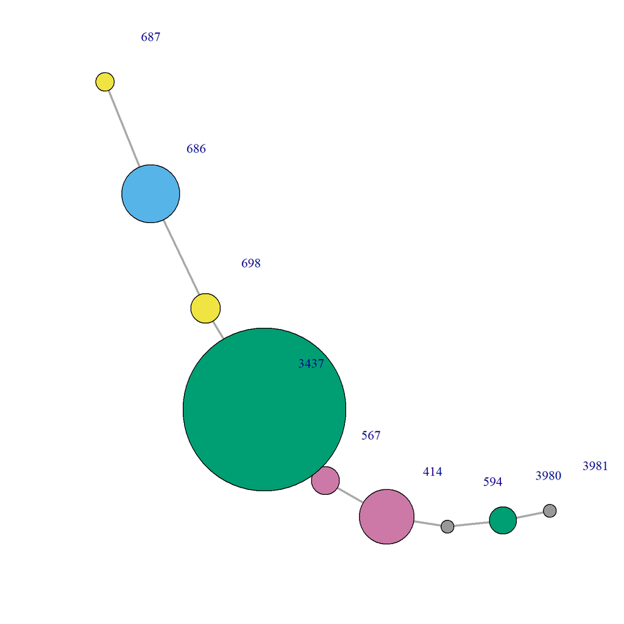

```r
plot(subgraph,
     vertex.size = V(subgraph)$vertex_degree/8 + 5,
     rescale=F,
     layout=lo,
     edge.width= 2.5,
     vertex.label.dist=4
     )
```

**e) Calculate the shortest path from the vertex named “1000” to the vertex named “2000” in the original file.**

```r
shortest = shortest_paths(undirected_graph,
                          from = V(undirected_graph)["1000"],
                          to  = V(undirected_graph)["2000"],
                          output = "both") # both path nodes and edges

#Camino más corto (en vertices): 1000 107  58   1912 2000
```

```r
#cliques(undirected_graph, min = 4)
```

**h) Calculate the list of names of verteces that are the neigbours of verteces of degree one and that are not of degree one.**

```r
V(undirected_graph)$degree = degree(undirected_graph, mode="all")

#Vertices cuyo grado es 1 (solo tienen 1 vecino)
vertices_1_grado = V(undirected_graph)[degree(undirected_graph)==1]
print(vertices_1_grado)
```

```
## + 75/4039 vertices, named, from 530d97e:
##  [1] 11   12   15   18   37   43   74   114  209  210  215  287  292  335  911
## [16] 918  1096 1119 1145 1206 1386 1466 1560 1581 1834 358  447  550  585  602
## [31] 607  608  613  624  638  668  674  692  801  875  883  891  892  2842 3031
## [46] 3071 3183 3230 2079 2195 2269 2457 2470 2569 2596 3451 3453 3570 3650 3709
## [61] 3729 3748 3798 3820 3853 3856 3935 3974 3984 4008 4010 4015 4022 4024 4035
```

```r
vecinos = adjacent_vertices(undirected_graph, v = vertices_1_grado)
vecinos = unlist(vecinos)

list = V(undirected_graph)[vecinos]
unique(list)
```

```
## + 10/4039 vertices, named, from 530d97e:
##  [1] 0    107  348  414  686  698  1684 1912 3437 3980
```

```r
#find_clique = function(graph, clique_size){
#g <- graph( edges=c(1,2, 2,3, 3,1), n=3, directed=F )
#plot(g)
```